# Project about students performance

Doroteja Vujinovic

6/13/2020

```r
knitr::opts_chunk$set(echo = TRUE)
library(tidyverse)
library(ggplot2)
data<-read.csv("StudentsPerformance.csv")
```

# Introduction

Data I choose to present is performance of 1000 US students on exams. Based on data that is provided on [this site](https://www.kaggle.com/datasets) we can see which factors have stronger impact on education, and if and how are exam results correlated.

# Presentation of the data

The data has eight variables and 1000 observations. The key variables include gender, race/ethnicity, parental level of education, lunch, test preparation course, math score, reading score and writing score.

```r
data%>%head(10)
```

```
##    gender race.ethnicity parental.level.of.education        lunch
## 1  female        group B           bachelor's degree     standard
## 2  female        group C                some college     standard
## 3  female        group B             master's degree     standard
## 4    male        group A          associate's degree free/reduced
## 5    male        group C                some college     standard
## 6  female        group B          associate's degree     standard
## 7  female        group B                some college     standard
## 8    male        group B                some college free/reduced
## 9    male        group D                 high school free/reduced
## 10 female        group B                 high school free/reduced
##    test.preparation.course math.score reading.score writing.score
## 1                     none         72            72            74
## 2                completed         69            90            88
## 3                     none         90            95            93
## 4                     none         47            57            44
## 5                     none         76            78            75
## 6                     none         71            83            78
## 7                completed         88            95            92
## 8                     none         40            43            39
## 9                completed         64            64            67
## 10                    none         38            60            50
```

```r
str(data)
```

```
## 'data.frame':    1000 obs. of  8 variables:
##  $ gender                     : Factor w/ 2 levels "female","male": 1 1 1 2 2 1 1 2 2 1 ...
##  $ race.ethnicity             : Factor w/ 5 levels "group A","group B",..: 2 3 2 1 3 2 2 2 4 2 ...
##  $ parental.level.of.education: Factor w/ 6 levels "associate's degree",..: 2 5 4 1 5 1 5 5 3 3 ...
##  $ lunch                      : Factor w/ 2 levels "free/reduced",..: 2 2 2 1 2 2 2 1 1 1 ...
##  $ test.preparation.course    : Factor w/ 2 levels "completed","none": 2 1 2 2 2 2 1 2 1 2 ...
##  $ math.score                 : int  72 69 90 47 76 71 88 40 64 38 ...
##  $ reading.score              : int  72 90 95 57 78 83 95 43 64 60 ...
##  $ writing.score              : int  74 88 93 44 75 78 92 39 67 50 ...
```

## Number of students by gender

### Visualisation

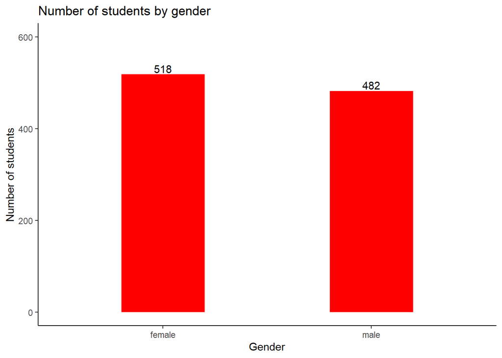

```r
data%>%ggplot()+geom_bar(aes(x=gender),width = 0.4, fill="red")+xlab("Gender")+ylab("Number of students")+theme_classic()+ylim(0,600)+ggtitle("Number of students by gender")+geom_text(stat = "count",aes(x=gender,label=..count..),vjust=-0.2)
```

### Conclusion/Interpretation

In the dataset we have 518 female students, and 482 male students, so the distribution is pretty symmetric.

## Number of students by race

### Visualisation

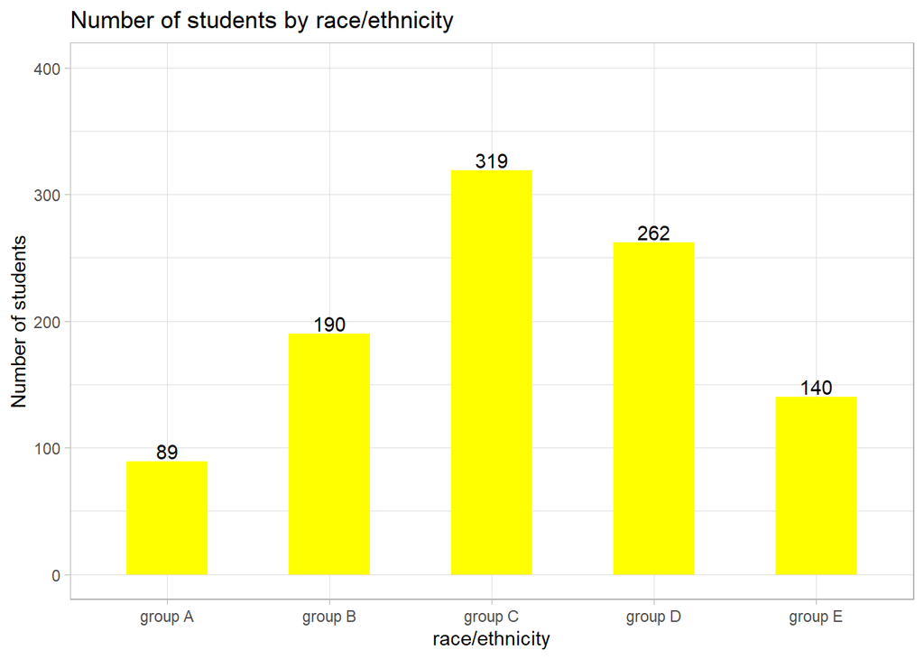

```r
data%>%ggplot()+geom_bar(aes(x=race.ethnicity),width = 0.5,fill="yellow")+ggtitle("Number of students by race/ethnicity")+xlab("race/ethnicity")+ylab("Number of students")+theme_light()+ylim(0,400)+geom_text(aes(x=race.ethnicity,label=..count..),vjust=-0.2,stat = "count")
```

### Conclusion/Interpretation

More than half of students are in groups C and D, while there is only 89 students in group A.

## Correlation between reading, writing and math score

### Visualisation

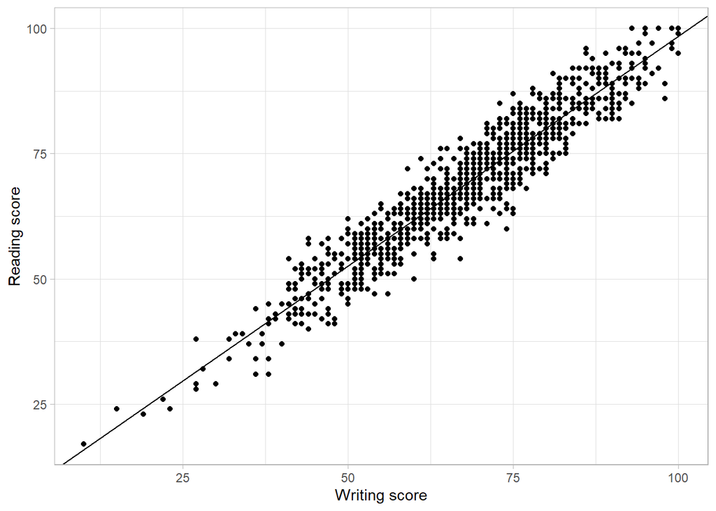

```r
line1<-lm(reading.score~writing.score, data = data)
slope1<-line1[[1]][2]
intercept1<-line1[[1]][1]
line2<-lm(reading.score~math.score, data = data)
slope2<-line2[[1]][2]
intercept2<-line2[[1]][1]
line3<-lm(writing.score~math.score, data = data)
slope3<-line3[[1]][2]
intercept3<-line3[[1]][1]
p1<-data%>%ggplot()+geom_point(aes(x=writing.score,y=reading.score))+theme_light()+xlab("Writing score")+ylab("Reading score")+geom_abline(slope = slope1, intercept = intercept1)
p2<-data%>%ggplot()+geom_point(aes(x=math.score,y=reading.score))+theme_light()+xlab("Math score")+ylab("Reading score")+geom_abline(slope = slope2,intercept = intercept2)
p3<-data%>%ggplot()+geom_point(aes(x=math.score,y=writing.score))+theme_light()+xlab("Math score")+ylab("Writing score")+geom_abline(slope = slope3,intercept =intercept3)
p1
```

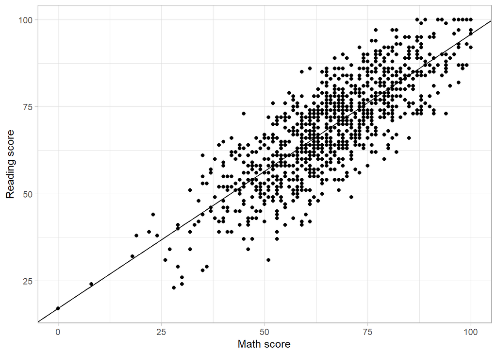

```r
p2
```

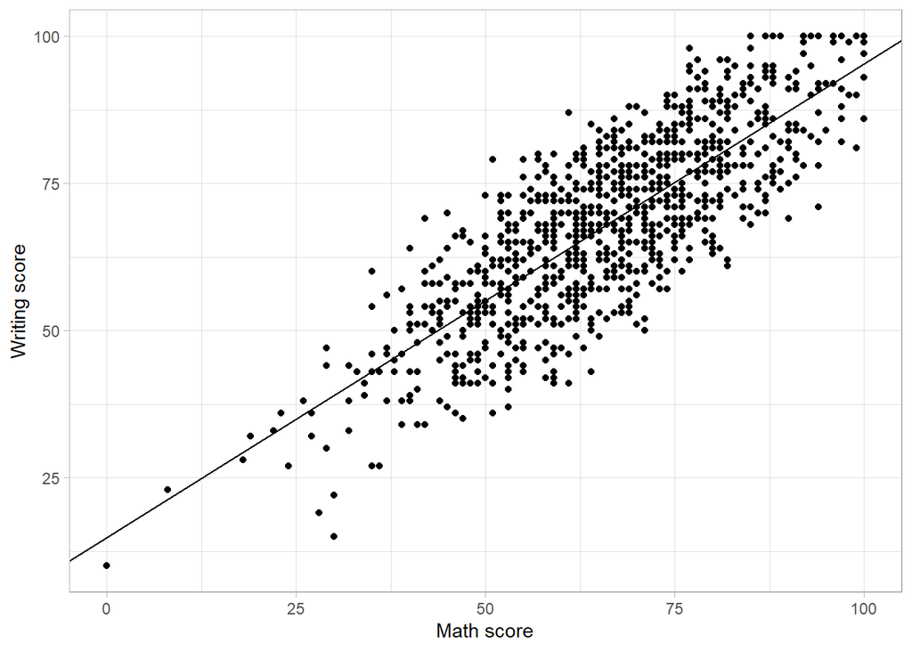

```r
p3
```

## Correlation test for given graphs (Exploratory data analysis)

```r
cor.test(data$writing.score,data$reading.score)
```

```
##
##  Pearson's product-moment correlation
##
## data:  data$writing.score and data$reading.score
## t = 101.23, df = 998, p-value < 2.2e-16
## alternative hypothesis: true correlation is not equal to 0
## 95 percent confidence interval:
##  0.9487506 0.9597921
## sample estimates:
##       cor
## 0.9545981
```

```r
cor.test(data$math.score,data$reading.score)
```

```
##
##  Pearson's product-moment correlation
##
## data:  data$math.score and data$reading.score
## t = 44.855, df = 998, p-value < 2.2e-16
## alternative hypothesis: true correlation is not equal to 0
## 95 percent confidence interval:
##  0.7959276 0.8371428
## sample estimates:
##       cor
## 0.8175797
```

```r
cor.test(data$writing.score,data$math.score)
```

```
##
##  Pearson's product-moment correlation
##
## data:  data$writing.score and data$math.score
## t = 42.511, df = 998, p-value < 2.2e-16
## alternative hypothesis: true correlation is not equal to 0
## 95 percent confidence interval:
##  0.7794321 0.8236517
## sample estimates:
##      cor
## 0.802642
```

### Conclusion/Interpretation

A scatter plot is used to represent correlation between two variables. There are two types of correlation: positive and negative. If variables move in same direction the correlation is positive, otherwise it is negative. In statistics, the Pearson correlation coefficient(PCC), is statistic that measures linear correlation between two variables. It has values between +1 and -1, where 1 is total positive linear correlation, 0 is no linear correlation, and -1 is total negative linear correlation. It is civariance of two variables divided by the product of their standard deviations. Our results are around 0.8 for correlation of math socres with reading and writing scores, and 0.95 between writing and reading scores which suggests really strong correlation.

## Impact of parental’s level of education

### Description of the problem

We want to check if parental’s level of education affects student’s result on exam.

### Exploratory data analysis

```r
data1<-data%>%mutate(StudentID = row_number()) %>%gather(key = "subject", value = "score", math.score:writing.score)
data1m<-data1%>%group_by(StudentID)%>%summarise(mean=mean(score))
final<-merge(data1m,data1[,c(1:6)],by="StudentID")%>%distinct(StudentID,.keep_all=TRUE)%>%group_by(parental.level.of.education)%>%summarise(average.score=mean(mean,na.rm = TRUE))%>%arrange(desc(average.score))
knitr::kable(final)
```

| parental.level.of.education | average.score |
| --- | --- |
| master’s degree | 73.59887 |
| bachelor’s degree | 71.92373 |
| associate’s degree | 69.56907 |
| some college | 68.47640 |
| some high school | 65.10801 |
| high school | 63.09694 |

### Conclusion/Interpretation

We can see that students whose parents have higher level of education tend to be more successful on exams in comparison with students whose parents have just finished high school, but the difference is not that big. We can conclude that level of parental’s education is not one of key factors for successful kid’s education.

## Average score by race

### Presentation and description of the problem

We saw that level of parental education is not significant and we would like to check what’s the case with race.

### Exploratory data analysis

```r
final1<-merge(data1m,data1[,c(1:6)],by="StudentID")%>%distinct(StudentID,.keep_all=TRUE)%>%group_by(race.ethnicity)%>%summarise(average.score=mean(mean,na.rm = TRUE))%>%arrange(desc(average.score))
knitr::kable(final1)
```

| race.ethnicity | average.score |
| --- | --- |
| group E | 72.75238 |
| group D | 69.17939 |
| group C | 67.13166 |
| group B | 65.46842 |
| group A | 62.99251 |

### Conclusion

Again, we didn’t manage to find significant relationship between variables. Group E shows best results, and group A worst, but they are 2 smallest groups, and difference is not that big.

## Impact of preparation course

### Presentation and description of the problem

We want to check if the students who complete preparation course show better results on the exam.

### Visualisation

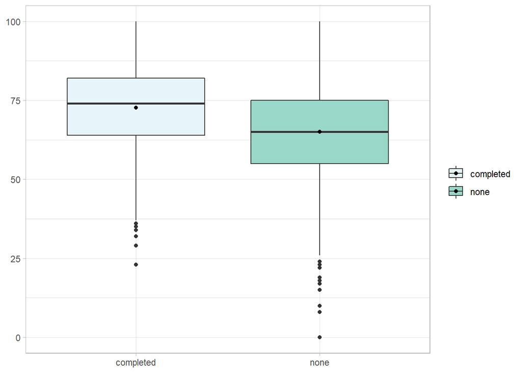

```r
data1%>%ggplot(aes(x=test.preparation.course,y=score,fill=test.preparation.course))+geom_boxplot()+theme_light()+xlab("Test preparation course")+ylab("Average score")+theme(title = element_blank())+scale_fill_brewer(type = "seq",palette = 2,aesthetics = "fill",direction = 1)+stat_summary(fun.y = mean,geom = "point")
```

### Conclusion/interpretation

Boxplots are standardized way of displaying of distribution of data based on five number summary (minimum, first quartile(25th percentile), median, third quartile(75th percentile), and maximum) Based on our data, we can conclude that average score of students who completed preparation course is much higher than the average score of students who did not. We can also see that students that didn’t complete preparation course have wider range of results, and more outliers below the minimum.

### Referencing

Wikipedia contributors (2020)

Galarnyk (2019)

# References

Galarnyk, Michael. 2019. “Understanding Boxplots.” *Medium*. Towards Data Science. [https://towardsdatascience.com/understanding-boxplots-5e2df7bcbd51#:~:text=The image above is a,and what their values are.](https://towardsdatascience.com/understanding-boxplots-5e2df7bcbd51#:~:text=The%20image%20above%20is%20a,and%20what%20their%20values%20are.)

Wikipedia contributors. 2020. “Pearson Correlation Coefficient — Wikipedia, the Free Encyclopedia.” https://en.wikipedia.org/w/index.php?title=Pearson_correlation_coefficient&oldid=958013974.